# Supplementary Materials

*Testing a rapid assessment approach for measuring ecosystem services in urban green alleys*

S2. Model diagnostic plots

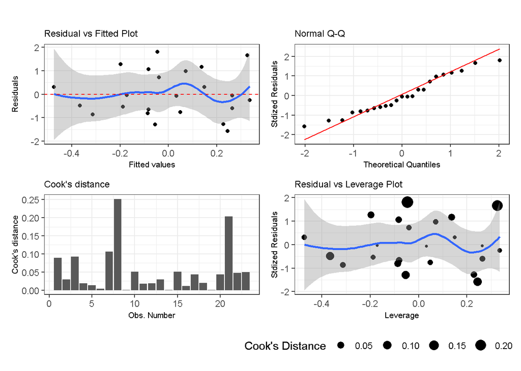

Figure 1. Diagnostic plots for average maximum temperature, as a function of ruelle length, ruelle area, average groundcover, average midstorey cover, and average canopy cover.

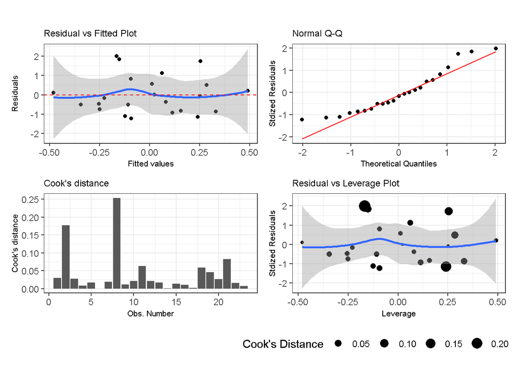

Figure 2. Diagnostic plots for average maximum temperature, as a function of percent vegetation, percent building, percent canopy, and road area within a 50 m buffer.

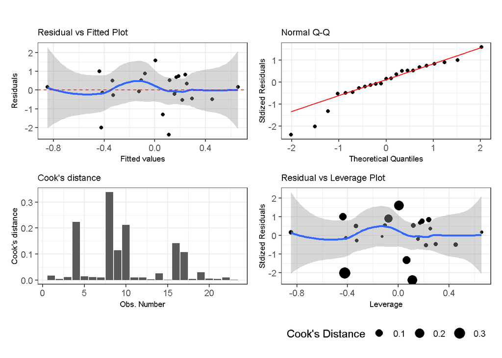

Figure 3. Diagnostic plots for average minimum temperature, as a function of ruelle length, ruelle area, average groundcover, average midstorey cover, and average canopy cover.

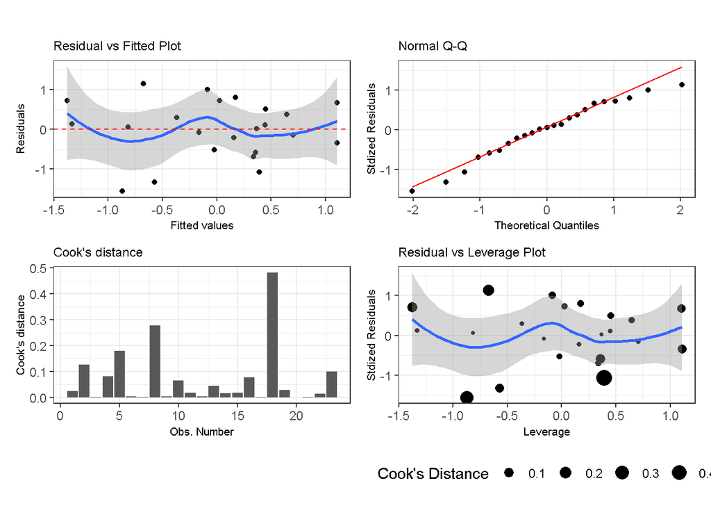

Figure 4. Diagnostic plots for average minimum temperature, as a function of percent vegetation, percent building, percent canopy, and road area within a 50 m buffer.

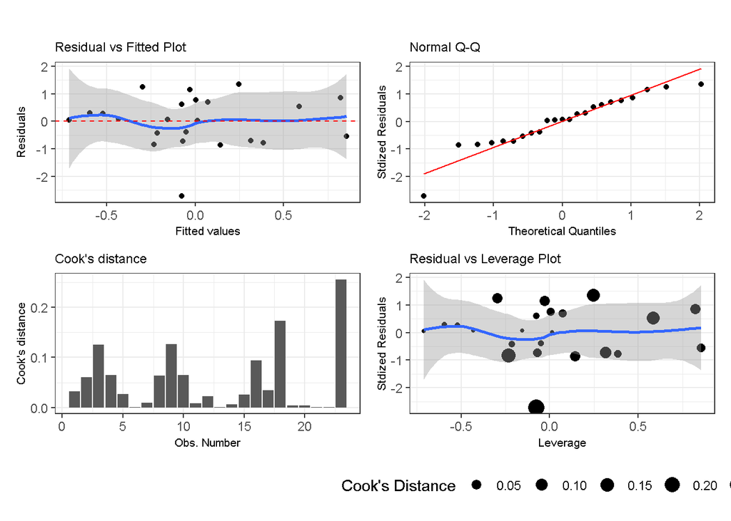

Figure 5. Diagnostic plots for average normalized difference sound index (NDSI), as a function of ruelle length, ruelle area, average groundcover, average midstorey cover, and average canopy cover.

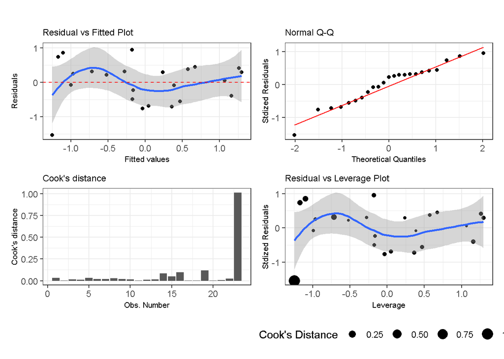

Figure 6. Diagnostic plots for average normalized difference sound index (NDSI), as a function of percent vegetation, percent building, percent canopy, and road area within a 50 m buffer.

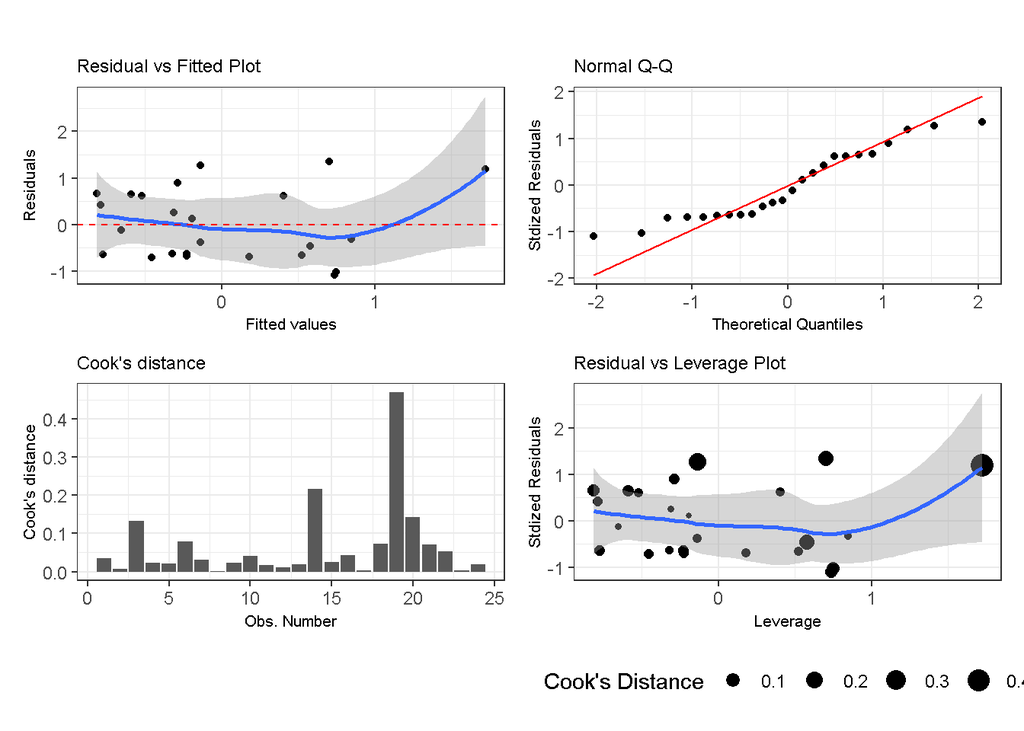

Figure 7. Diagnostic plots for floral coverage (per m2), as a function of ruelle length, ruelle area, average groundcover, average midstorey cover, and average canopy cover.

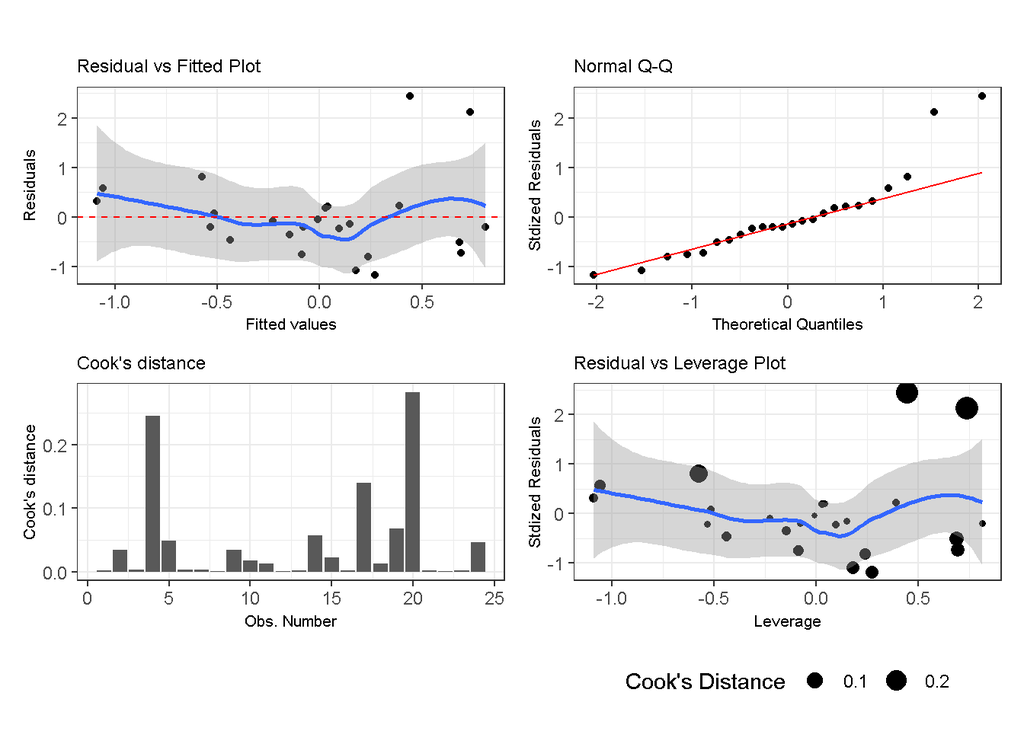

Figure 8. Diagnostic plots for food coverage (per m2), as a function of ruelle length, ruelle area, average groundcover, average midstorey cover, and average canopy cover.